# Anova

Daniel Miranda

2026

# Ejemplo Anova

## Lectura de datos

```r
library(skimr)
library(psych)
library(ggplot2)
library(texreg)
library(car)
library(dplyr)
library(rempsyc)
library(flextable)
library(rio)
library(gridExtra)
library(lsr)
#install.packages("flextable")
#install.packages("multcompView")
#install.packages("rempsyc")

#getwd()
anova1=import("./anova_I.xlsx", sep=";")
names(anova1)
```

```
## [1] "ID"        "bienestar" "Grupo"
```

```r
anova2=read.csv("./anova_sueno.csv", sep=";")
names(anova2)
```

```
## [1] "id"    "vd"    "grupo"
```

## Describir base de datos

```r
anova1 %>%
  skim(bienestar)
```

Data summary

| Name | Piped data |
| --- | --- |
| Number of rows | 16 |
| Number of columns | 3 |
| _______________________ |  |
| Column type frequency: |  |
| numeric | 1 |
| ________________________ |  |
| Group variables | None |

**Variable type: numeric**

| skim_variable | n_missing | complete_rate | mean | sd | p0 | p25 | p50 | p75 | p100 | hist |
| --- | --- | --- | --- | --- | --- | --- | --- | --- | --- | --- |
| bienestar | 0 | 1 | 5.44 | 2.85 | 2 | 3 | 4.5 | 8 | 10 | ▇▃▁▃▃ |

```r
anova1 %>%
  group_by(Grupo) %>%
  skim(bienestar)
```

Data summary

| Name | Piped data |
| --- | --- |
| Number of rows | 16 |
| Number of columns | 3 |
| _______________________ |  |
| Column type frequency: |  |
| numeric | 1 |
| ________________________ |  |
| Group variables | Grupo |

**Variable type: numeric**

| skim_variable | Grupo | n_missing | complete_rate | mean | sd | p0 | p25 | p50 | p75 | p100 | hist |
| --- | --- | --- | --- | --- | --- | --- | --- | --- | --- | --- | --- |
| bienestar | control | 0 | 1 | 3.00 | 0.82 | 2 | 2.75 | 3.0 | 3.25 | 4 | ▃▁▇▁▃ |
| bienestar | gato | 0 | 1 | 5.25 | 1.71 | 3 | 4.50 | 5.5 | 6.25 | 7 | ▇▁▇▇▇ |
| bienestar | otro | 0 | 1 | 4.25 | 2.63 | 2 | 2.75 | 3.5 | 5.00 | 8 | ▇▃▁▁▃ |
| bienestar | perro | 0 | 1 | 9.25 | 0.96 | 8 | 8.75 | 9.5 | 10.00 | 10 | ▃▁▃▁▇ |

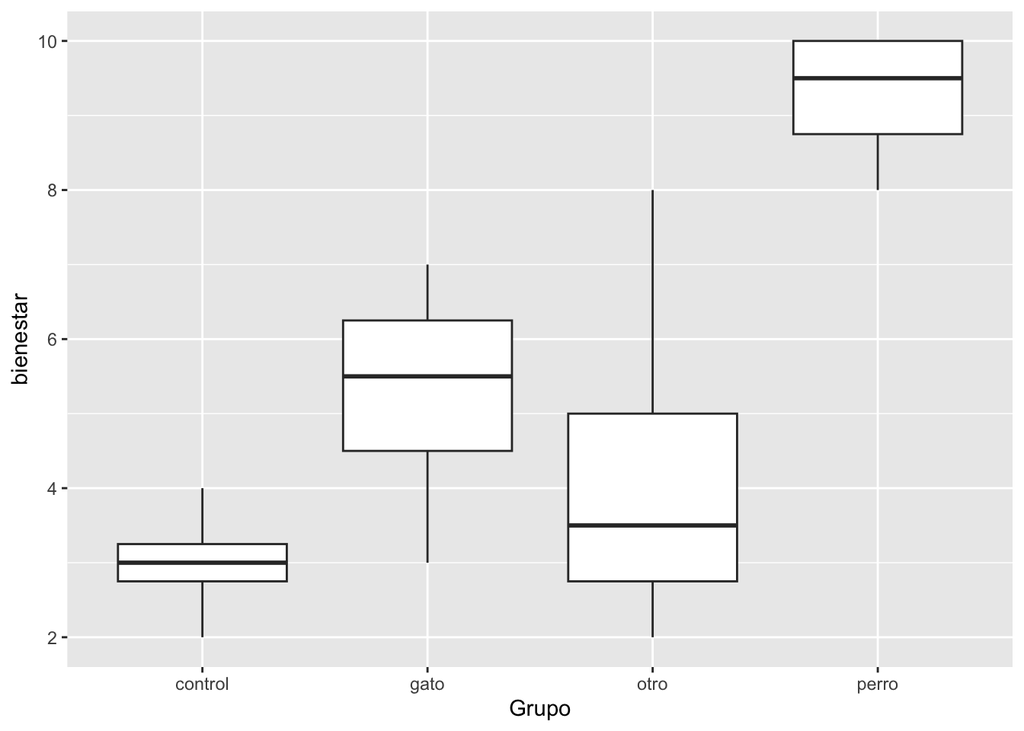

```r
ggplot(anova1, aes(y=bienestar, x=Grupo)) +
  geom_boxplot()
```

## Estimación del modelo

```r
# Modelo anova
mod1= aov(bienestar ~ Grupo, data=anova1)
summary(mod1)
```

```
##             Df Sum Sq Mean Sq F value  Pr(>F)
## Grupo        3  87.69  29.229   10.24 0.00125 **
## Residuals   12  34.25   2.854
## ---
## Signif. codes:  0 '***' 0.001 '**' 0.01 '*' 0.05 '.' 0.1 ' ' 1
```

```r
sstable <- Anova(mod1, type = 2)

nice_table(sstable)
```

| Sum Sq | Df | F value | Pr(>F) |
| --- | --- | --- | --- |
| 87.69 | 3.00 | 10.24 | 0.00 |
| 34.25 | 12.00 |  |  |

```r
knitr::kable(sstable, digits = 3)
```

|  | Sum Sq | Df | F value | Pr(>F) |
| --- | --- | --- | --- | --- |
| Grupo | 87.688 | 3 | 10.241 | 0.001 |
| Residuals | 34.250 | 12 | NA | NA |

```r
# F_crítico
qf(0.05, 4-1, 16-4, lower.tail = F)
```

```
## [1] 3.490295
```

Comparar F observado(10.24) vs F crítico(3.49)

## Describir base de datos

```r
anova2 %>%
  skim(vd)
```

Data summary

| Name | Piped data |
| --- | --- |
| Number of rows | 60 |
| Number of columns | 3 |
| _______________________ |  |
| Column type frequency: |  |
| numeric | 1 |
| ________________________ |  |
| Group variables | None |

**Variable type: numeric**

| skim_variable | n_missing | complete_rate | mean | sd | p0 | p25 | p50 | p75 | p100 | hist |
| --- | --- | --- | --- | --- | --- | --- | --- | --- | --- | --- |
| vd | 0 | 1 | 4.37 | 2.13 | 1 | 3 | 4 | 6 | 10 | ▅▇▆▂▁ |

```r
anova2 %>%
  group_by(grupo) %>%
  skim(vd)
```

Data summary

| Name | Piped data |
| --- | --- |
| Number of rows | 60 |
| Number of columns | 3 |
| _______________________ |  |
| Column type frequency: |  |
| numeric | 1 |
| ________________________ |  |
| Group variables | grupo |

**Variable type: numeric**

| skim_variable | grupo | n_missing | complete_rate | mean | sd | p0 | p25 | p50 | p75 | p100 | hist |
| --- | --- | --- | --- | --- | --- | --- | --- | --- | --- | --- | --- |
| vd | C | 0 | 1 | 3.00 | 1.51 | 1 | 2.0 | 3 | 3.5 | 7 | ▇▅▂▁▁ |
| vd | EN | 0 | 1 | 3.27 | 1.44 | 1 | 2.5 | 3 | 4.0 | 6 | ▆▇▅▃▂ |
| vd | EP | 0 | 1 | 4.73 | 1.49 | 2 | 4.0 | 5 | 6.0 | 7 | ▆▇▆▆▃ |
| vd | IS | 0 | 1 | 6.47 | 2.10 | 3 | 5.0 | 6 | 8.0 | 10 | ▃▅▇▃▅ |

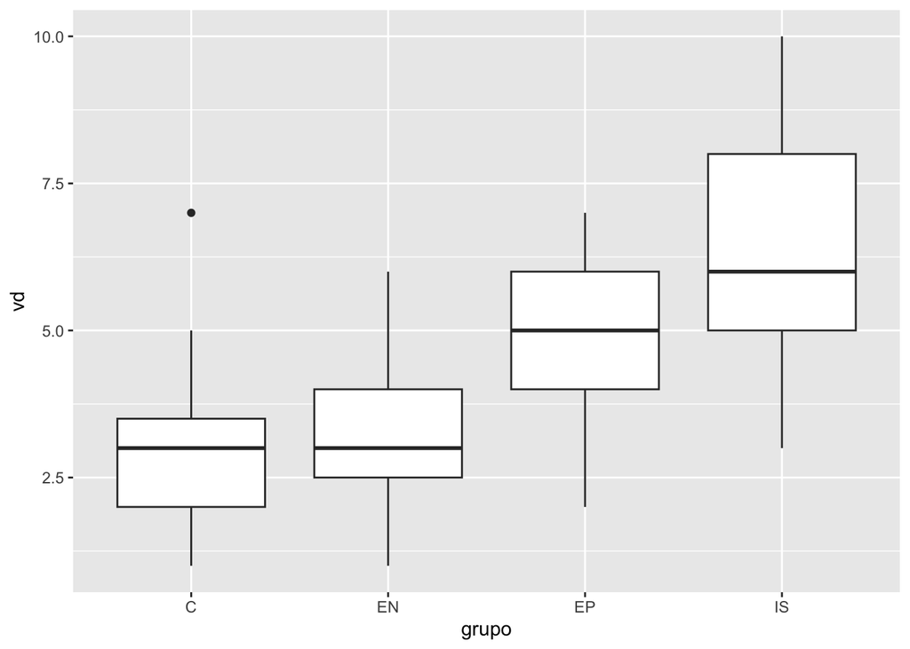

```r
ggplot(anova2, aes(y=vd, x=grupo)) +
  geom_boxplot()
```

## Estimación del modelo

```r
# Modelo anova
mod1= aov(vd ~ grupo, data=anova2)
summary(mod1)
```

```
##             Df Sum Sq Mean Sq F value   Pr(>F)
## grupo        3  114.3   38.11    13.9 6.93e-07 ***
## Residuals   56  153.6    2.74
## ---
## Signif. codes:  0 '***' 0.001 '**' 0.01 '*' 0.05 '.' 0.1 ' ' 1
```

```r
sstable <- Anova(mod1, type = 2)

nice_table(sstable)
```

| Sum Sq | Df | F value | Pr(>F) |
| --- | --- | --- | --- |
| 114.33 | 3.00 | 13.89 | 0.00 |
| 153.60 | 56.00 |  |  |

```r
knitr::kable(sstable, digits = 3)
```

|  | Sum Sq | Df | F value | Pr(>F) |
| --- | --- | --- | --- | --- |
| grupo | 114.333 | 3 | 13.895 | 0 |
| Residuals | 153.600 | 56 | NA | NA |

```r
# F_crítico
qf(0.05, 3-1, 60-4, lower.tail = F)
```

```
## [1] 3.161861
```

Comparar F observado(13.89) vs F crítico(3.16)

## Chequeo de Supuestos

### Normalidad

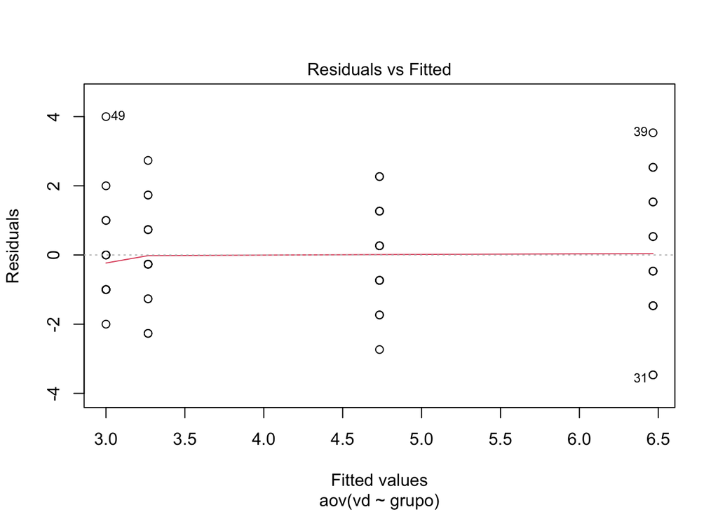

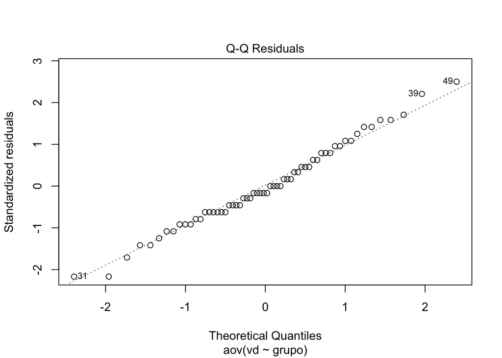

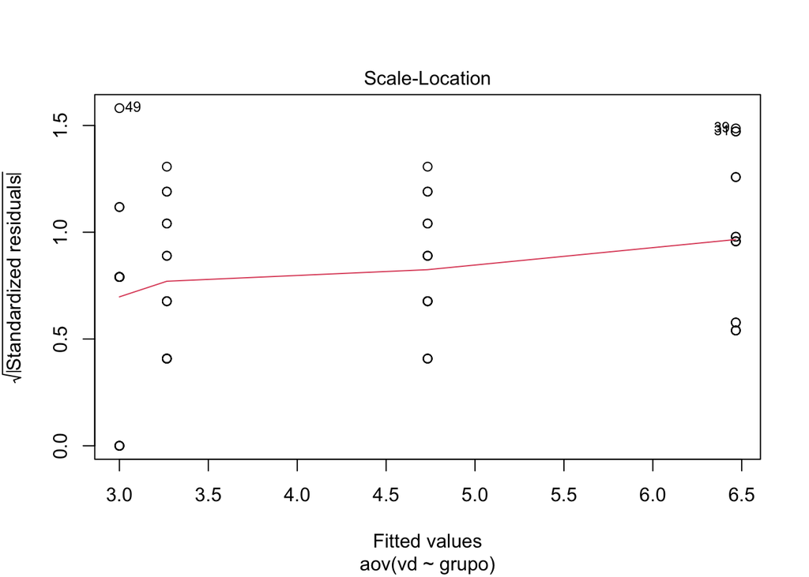

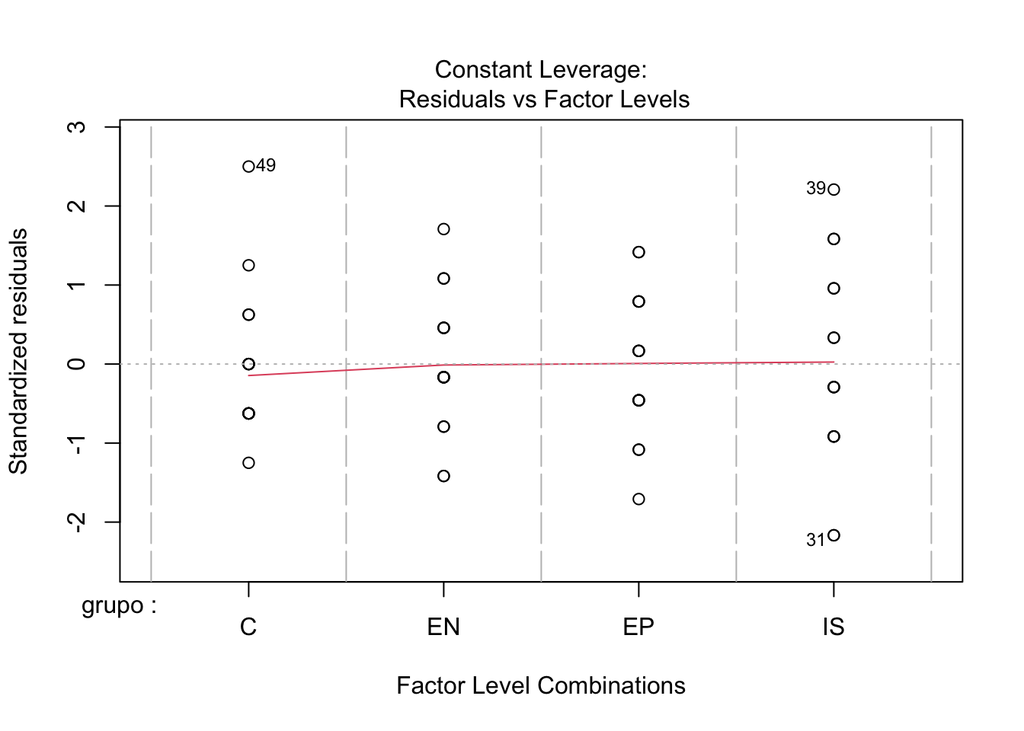

```r
plot(mod1)
```

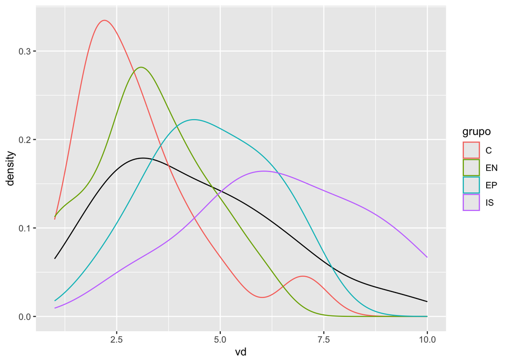

```r
#histogram(mod1$residuals)

ggplot(anova2) +
  geom_density(aes(x=vd))+
  geom_density(aes(vd, group=grupo, color=grupo))
```

```r
shapiro.test(mod1$residuals)
```

```
##
##  Shapiro-Wilk normality test
##
## data:  mod1$residuals
## W = 0.98784, p-value = 0.814
```

```r
shapiro.test(subset(mod1$residuals, subset = anova2$grupo == "C"))
```

```
##
##  Shapiro-Wilk normality test
##
## data:  subset(mod1$residuals, subset = anova2$grupo == "C")
## W = 0.8526, p-value = 0.01891
```

```r
shapiro.test(subset(mod1$residuals, subset = anova2$grupo == "EN"))
```

```
##
##  Shapiro-Wilk normality test
##
## data:  subset(mod1$residuals, subset = anova2$grupo == "EN")
## W = 0.95073, p-value = 0.536
```

```r
shapiro.test(subset(mod1$residuals, subset = anova2$grupo == "EP"))
```

```
##
##  Shapiro-Wilk normality test
##
## data:  subset(mod1$residuals, subset = anova2$grupo == "EP")
## W = 0.951, p-value = 0.5403
```

```r
shapiro.test(subset(mod1$residuals, subset = anova2$grupo == "IS"))
```

```
##
##  Shapiro-Wilk normality test
##
## data:  subset(mod1$residuals, subset = anova2$grupo == "IS")
## W = 0.95742, p-value = 0.6476
```

### Homocedasticidad

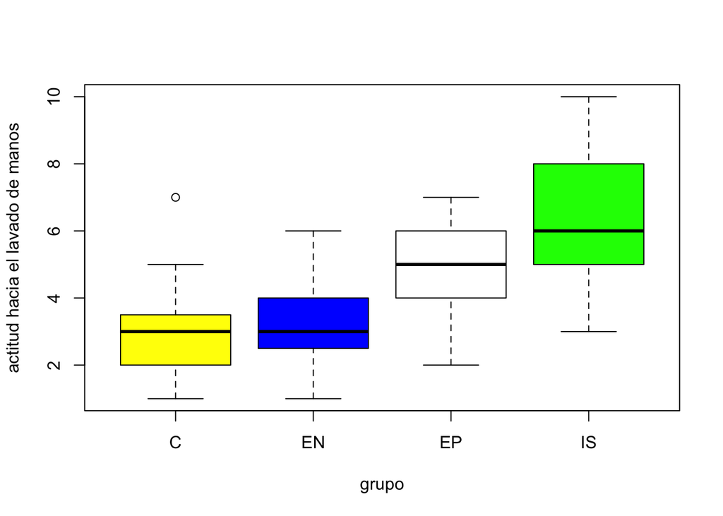

```r
boxplot(vd~ grupo, data=anova2, col = c("yellow", "blue", "white","green"), ylab = "actitud hacia el lavado de manos")
```

```r
leveneTest(vd ~ grupo, data=anova2)
```

```
## Levene's Test for Homogeneity of Variance (center = median)
##       Df F value Pr(>F)
## group  3  1.1061 0.3544
##       56
```

```r
bartlett.test(vd ~ grupo, data = anova2 )
```

```
##
##  Bartlett test of homogeneity of variances
##
## data:  vd by grupo
## Bartlett's K-squared = 2.8121, df = 3, p-value = 0.4215
```

```r
oneway.test(vd ~ grupo, data=anova2, var.equal = TRUE)
```

```
##
##  One-way analysis of means
##
## data:  vd and grupo
## F = 13.895, num df = 3, denom df = 56, p-value = 6.931e-07
```

## Contrastes post-hoc

Si hemos detectado diferencias significativas entre los tipos de sensibilizaciones. ¿Sería posible saber cuáles son los grupos que generan estas diferencias?

```r
pairwise.t.test( anova2$vd,
                 anova2$grupo,
                 p.adj = "bonferroni")
```

```
##
##  Pairwise comparisons using t tests with pooled SD
##
## data:  anova2$vd and anova2$grupo
##
##    C       EN      EP
## EN 1.000   -       -
## EP 0.035   0.111   -
## IS 2.5e-06 1.3e-05 0.035
##
## P value adjustment method: bonferroni
```

```r
intervalos= TukeyHSD(mod1)
intervalos
```

```
##   Tukey multiple comparisons of means
##     95% family-wise confidence level
##
## Fit: aov(formula = vd ~ grupo, data = anova2)
##
## $grupo
##            diff        lwr      upr     p adj
## EN-C  0.2666667 -1.3346251 1.867958 0.9710793
## EP-C  1.7333333  0.1320416 3.334625 0.0289845
## IS-C  3.4666667  1.8653749 5.067958 0.0000024
## EP-EN 1.4666667 -0.1346251 3.067958 0.0839097
## IS-EN 3.2000000  1.5987083 4.801292 0.0000122
## IS-EP 1.7333333  0.1320416 3.334625 0.0289845
```

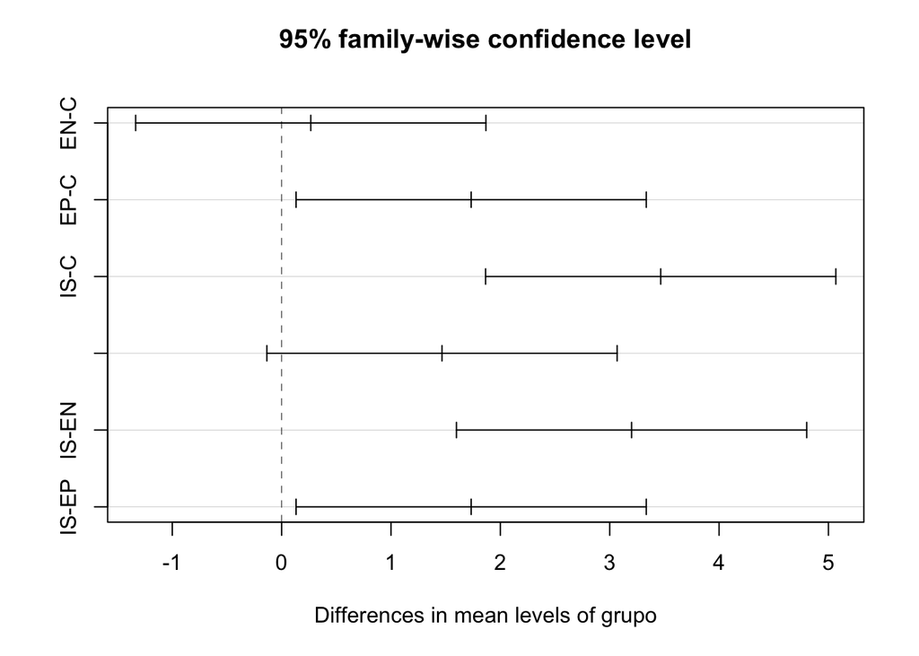

```r
plot(intervalos)
```

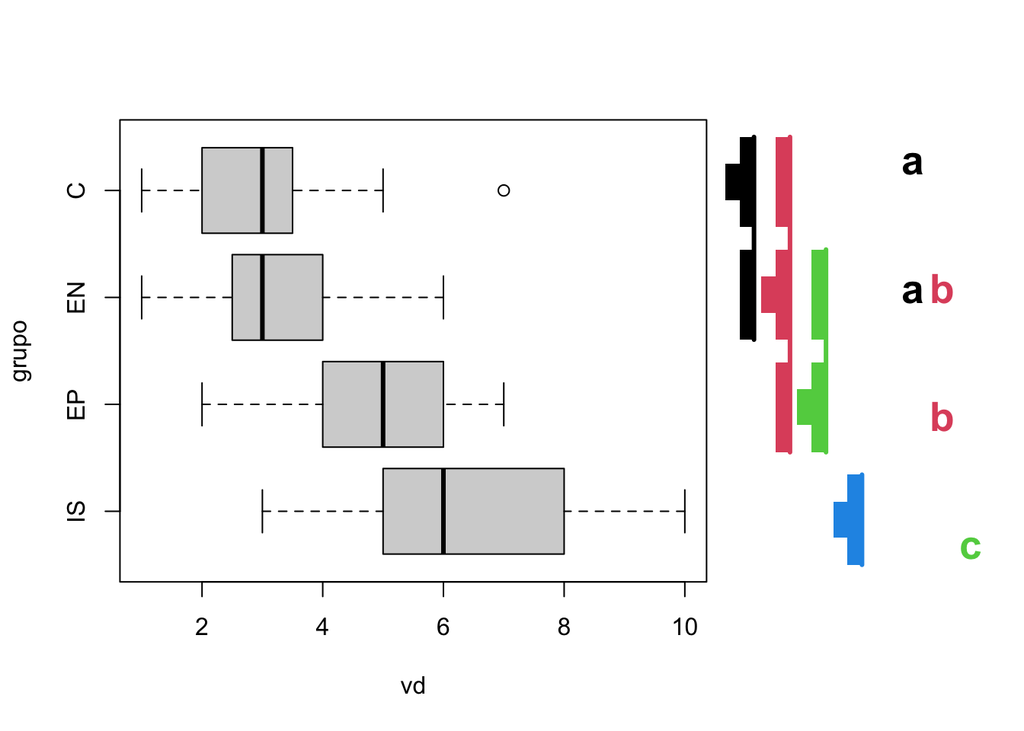

```r
library(multcompView)
multcompBoxplot(vd~ grupo, data=anova2, compFn = "TukeyHSD")
```

## Contrastes planificados

```r
table(anova2$grupo)

summary.lm(mod1)


means= emmeans(mod1, specs =~grupo)
Contraste1 = list(control_vs_todos  = c(-3,1,1,1))

contrast(means, Contraste1)

Contraste2 = list(EN_vs_EPIS  = c(0,-2,1,1))

contrast(means, Contraste2)

Contraste3 = list(EN_vs_EPIS  = c(0,0,-1,1))

contrast(means, Contraste3)
```

```r
contrast1 <- c(-3, 1, 1, 1)
contrast2 <- c(0,-2, 1, 1)
contrast3 <- c(0, 0, -1, 1)


str(anova2)
```

```
## 'data.frame':    60 obs. of  3 variables:
##  $ id   : int  1 2 3 4 5 6 7 8 9 10 ...
##  $ vd   : int  4 5 7 4 3 5 6 2 6 5 ...
##  $ grupo: chr  "EP" "EP" "EP" "EP" ...
```

```r
View(anova2)
anova2$grupof= as.factor(anova2$grupo)
contrasts(anova2$grupof) <- cbind(contrast1, contrast2, contrast3)
anova2$grupof
```

```
##  [1] EP EP EP EP EP EP EP EP EP EP EP EP EP EP EP EN EN EN EN EN EN EN EN EN EN
## [26] EN EN EN EN EN IS IS IS IS IS IS IS IS IS IS IS IS IS IS IS C  C  C  C  C
## [51] C  C  C  C  C  C  C  C  C  C
## attr(,"contrasts")
##    contrast1 contrast2 contrast3
## C         -3         0         0
## EN         1        -2         0
## EP         1         1        -1
## IS         1         1         1
## Levels: C EN EP IS
```

```r
planificado <- aov(vd ~ grupof, data=anova2)
summary.lm(planificado)
```

```
##
## Call:
## aov(formula = vd ~ grupof, data = anova2)
##
## Residuals:
##     Min      1Q  Median      3Q     Max
## -3.4667 -1.0000 -0.2667  1.0667  4.0000
##
## Coefficients:
##                 Estimate Std. Error t value Pr(>|t|)
## (Intercept)       4.3667     0.2138  20.423  < 2e-16 ***
## grupofcontrast1   0.4556     0.1234   3.690 0.000509 ***
## grupofcontrast2   0.7778     0.1746   4.455 4.06e-05 ***
## grupofcontrast3   0.8667     0.3024   2.866 0.005842 **
## ---
## Signif. codes:  0 '***' 0.001 '**' 0.01 '*' 0.05 '.' 0.1 ' ' 1
##
## Residual standard error: 1.656 on 56 degrees of freedom
## Multiple R-squared:  0.4267, Adjusted R-squared:  0.396
## F-statistic: 13.89 on 3 and 56 DF,  p-value: 6.931e-07
```

## Otro ejemplo

```r
anova3=read.csv("./autoef.csv", sep=";")
names(anova2)
```

```
## [1] "id"     "vd"     "grupo"  "grupof"
```

```r
anova3 %>%
  skim(bienestar)
```

Data summary

| Name | Piped data |
| --- | --- |
| Number of rows | 20 |
| Number of columns | 3 |
| _______________________ |  |
| Column type frequency: |  |
| numeric | 1 |
| ________________________ |  |
| Group variables | None |

**Variable type: numeric**

| skim_variable | n_missing | complete_rate | mean | sd | p0 | p25 | p50 | p75 | p100 | hist |
| --- | --- | --- | --- | --- | --- | --- | --- | --- | --- | --- |
| bienestar | 0 | 1 | 15.05 | 6.57 | 6 | 9.75 | 14.5 | 19.25 | 27 | ▇▃▃▃▅ |

```r
anova3 %>%
  group_by(Grupo) %>%
  skim(bienestar)
```

Data summary

| Name | Piped data |
| --- | --- |
| Number of rows | 20 |
| Number of columns | 3 |
| _______________________ |  |
| Column type frequency: |  |
| numeric | 1 |
| ________________________ |  |
| Group variables | Grupo |

**Variable type: numeric**

| skim_variable | Grupo | n_missing | complete_rate | mean | sd | p0 | p25 | p50 | p75 | p100 | hist |
| --- | --- | --- | --- | --- | --- | --- | --- | --- | --- | --- | --- |
| bienestar | 1problema | 0 | 1 | 19.00 | 0.82 | 18 | 18.75 | 19.0 | 19.25 | 20 | ▃▁▇▁▃ |
| bienestar | 2problema | 0 | 1 | 14.50 | 1.29 | 13 | 13.75 | 14.5 | 15.25 | 16 | ▇▇▁▇▇ |
| bienestar | 3problema | 0 | 1 | 10.00 | 0.82 | 9 | 9.75 | 10.0 | 10.25 | 11 | ▃▁▇▁▃ |
| bienestar | 4problema | 0 | 1 | 7.00 | 0.82 | 6 | 6.75 | 7.0 | 7.25 | 8 | ▃▁▇▁▃ |
| bienestar | control | 0 | 1 | 24.75 | 1.71 | 23 | 23.75 | 24.5 | 25.50 | 27 | ▇▇▇▁▇ |

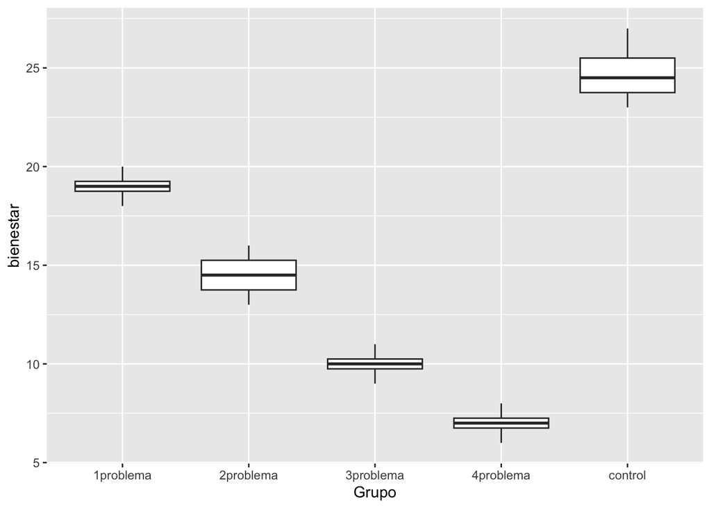

```r
ggplot(anova3, aes(y=bienestar, x=Grupo)) +
  geom_boxplot()
```

```r
mod2= aov(bienestar ~ Grupo, data=anova3)
summary(mod2)
```

```
##             Df Sum Sq Mean Sq F value   Pr(>F)
## Grupo        4  801.2  200.30   152.1 6.02e-12 ***
## Residuals   15   19.7    1.32
## ---
## Signif. codes:  0 '***' 0.001 '**' 0.01 '*' 0.05 '.' 0.1 ' ' 1
```

```r
sstable <- Anova(mod2, type = 2)

nice_table(sstable)
```

| Sum Sq | Df | F value | Pr(>F) |
| --- | --- | --- | --- |
| 801.20 | 4.00 | 152.13 | 0.00 |
| 19.75 | 15.00 |  |  |

```r
knitr::kable(sstable, digits = 3)
```

|  | Sum Sq | Df | F value | Pr(>F) |
| --- | --- | --- | --- | --- |
| Grupo | 801.20 | 4 | 152.127 | 0 |
| Residuals | 19.75 | 15 | NA | NA |

```r
# F_crítico
qf(0.05, 5-1, 20-5, lower.tail = F)
```

```
## [1] 3.055568
```

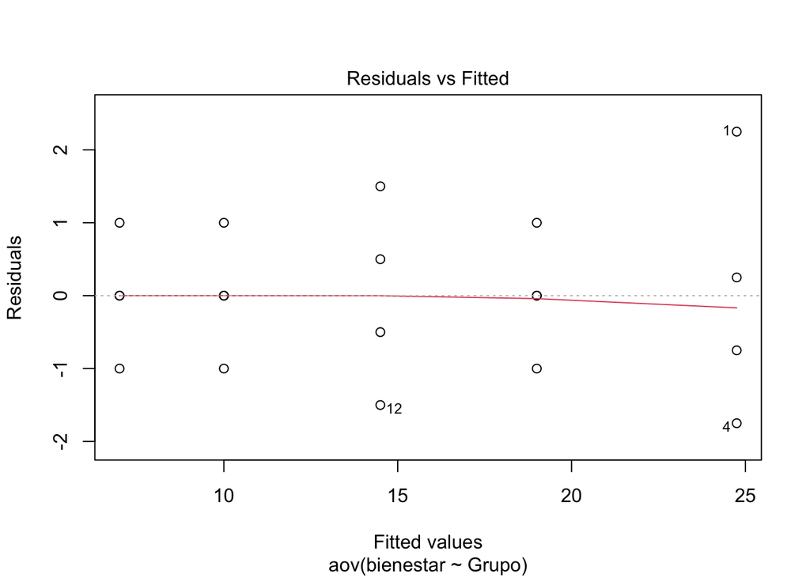

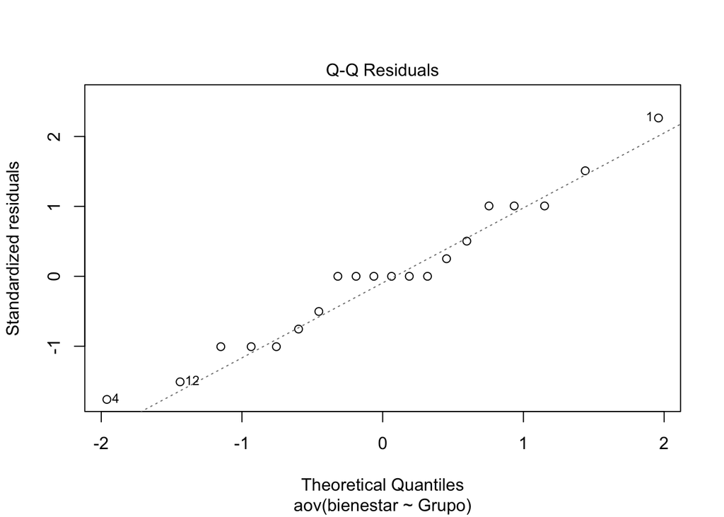

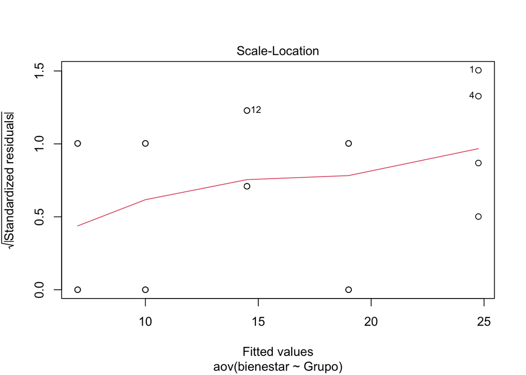

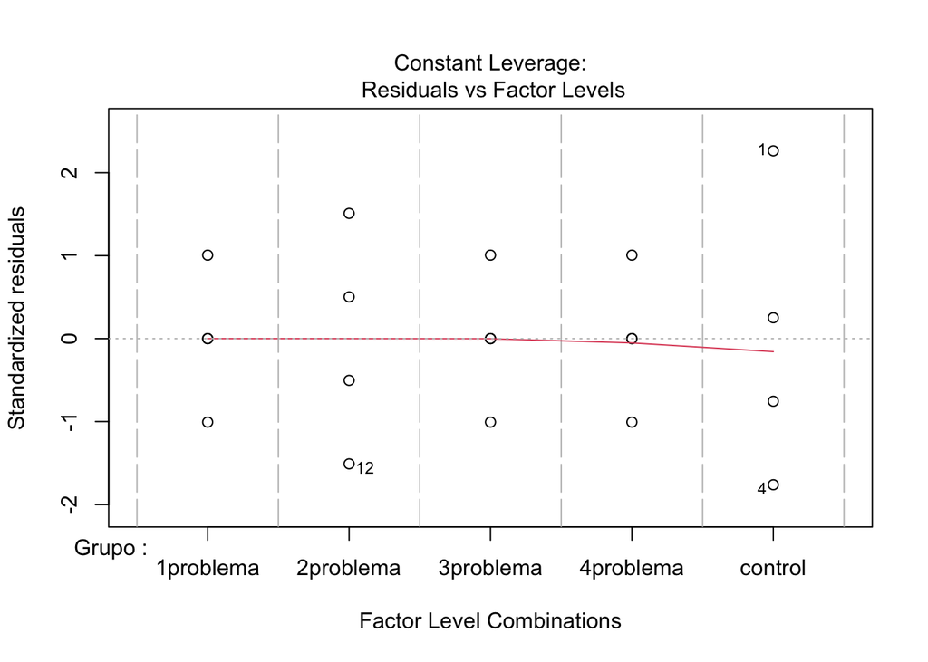

```r
plot(mod2)
```

```r
shapiro.test(mod2$residuals)
```

```
##
##  Shapiro-Wilk normality test
##
## data:  mod2$residuals
## W = 0.9656, p-value = 0.6606
```

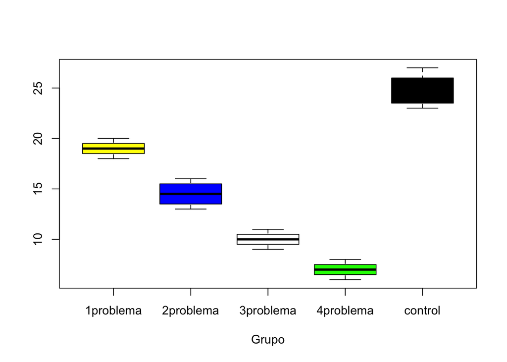

```r
boxplot(bienestar~ Grupo, data=anova3, col = c("yellow", "blue", "white","green", "black"), ylab = "")
```

```r
leveneTest(bienestar~ Grupo, data=anova3)
```

```
## Levene's Test for Homogeneity of Variance (center = median)
##       Df F value Pr(>F)
## group  4  1.1111 0.3876
##       15
```

```r
bartlett.test(bienestar~ Grupo, data=anova3 )
```

```
##
##  Bartlett test of homogeneity of variances
##
## data:  bienestar by Grupo
## Bartlett's K-squared = 2.6752, df = 4, p-value = 0.6136
```

```r
oneway.test(bienestar~ Grupo, data=anova3, var.equal = TRUE)
```

```
##
##  One-way analysis of means
##
## data:  bienestar and Grupo
## F = 152.13, num df = 4, denom df = 15, p-value = 6.018e-12
```

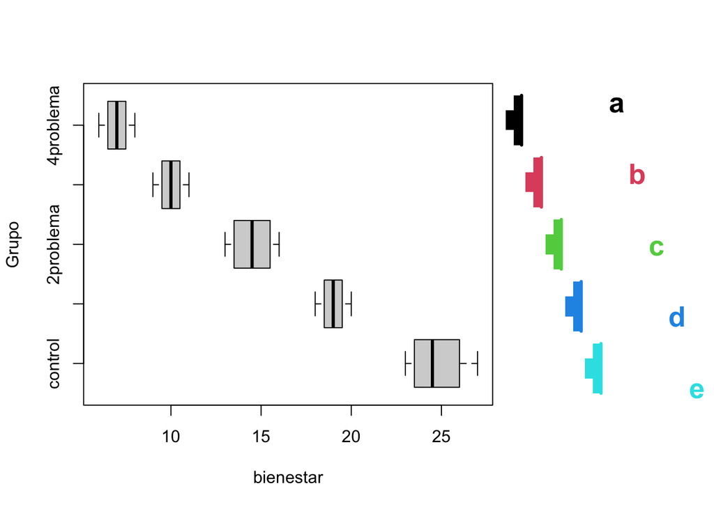

```r
multcompBoxplot(bienestar~ Grupo, data=anova3)
```

```r
pairwise.t.test( anova3$bienestar,
                 anova3$Grupo,
                 p.adj = "bonferroni")
```

```
##
##  Pairwise comparisons using t tests with pooled SD
##
## data:  anova3$bienestar and anova3$Grupo
##
##           1problema 2problema 3problema 4problema
## 2problema 0.00056   -         -         -
## 3problema 1.3e-07   0.00056   -         -
## 4problema 2.4e-09   1.4e-06   0.02150   -
## control   3.7e-05   2.1e-08   1.3e-10   8.6e-12
##
## P value adjustment method: bonferroni
```

```r
intervalos= TukeyHSD(mod2)
intervalos
```

```
##   Tukey multiple comparisons of means
##     95% family-wise confidence level
##
## Fit: aov(formula = bienestar ~ Grupo, data = anova3)
##
## $Grupo
##                       diff        lwr        upr     p adj
## 2problema-1problema  -4.50  -7.005472 -1.9945278 0.0004606
## 3problema-1problema  -9.00 -11.505472 -6.4945278 0.0000001
## 4problema-1problema -12.00 -14.505472 -9.4945278 0.0000000
## control-1problema     5.75   3.244528  8.2554722 0.0000317
## 3problema-2problema  -4.50  -7.005472 -1.9945278 0.0004606
## 4problema-2problema  -7.50 -10.005472 -4.9945278 0.0000012
## control-2problema    10.25   7.744528 12.7554722 0.0000000
## 4problema-3problema  -3.00  -5.505472 -0.4945278 0.0156512
## control-3problema    14.75  12.244528 17.2554722 0.0000000
## control-4problema    17.75  15.244528 20.2554722 0.0000000
```

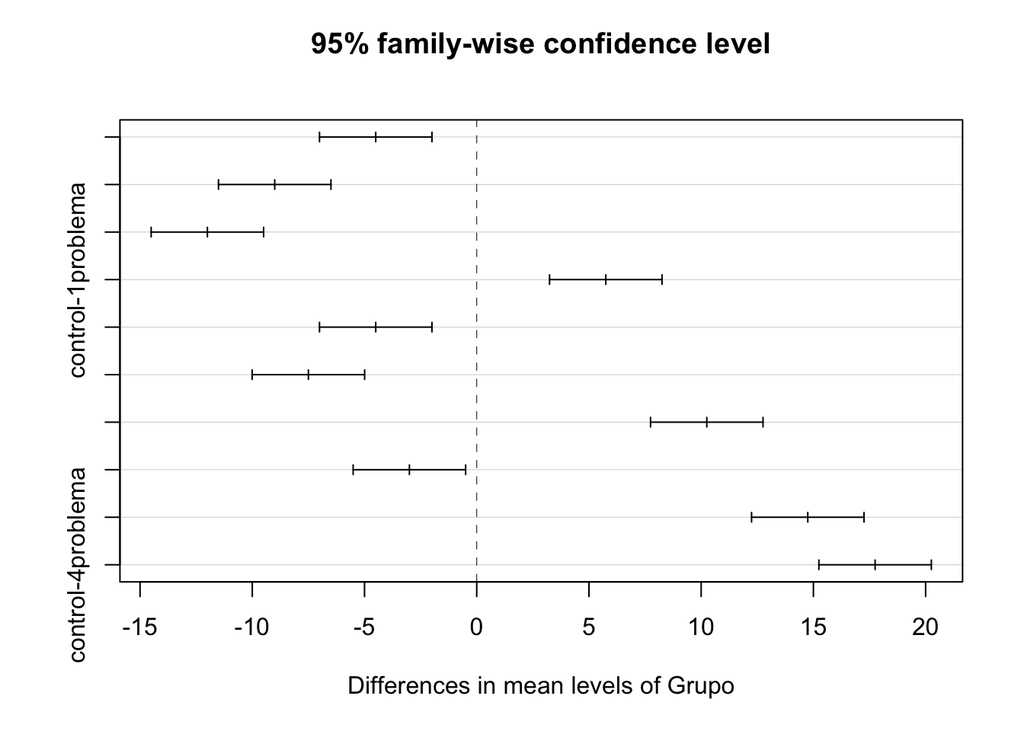

```r
plot(intervalos)
```

## Anova Factorial o de una dos vías

Supóngase un estudio clínico que analiza la eficacia de un medicamento teniendo en cuenta dos factores, el sexo (masculino y femenino) y la juventud (joven, adulto). Se quiere analizar si el efecto es diferente entre alguno de los niveles de cada variable por si sola o en combinación.

Este estudio implica comprobar si el efecto medio del fármaco es significativamente distinto entre alguno de los siguientes grupos: hombres, mujeres, jóvenes, adultos, hombres jóvenes, hombres adultos, mujeres jóvenes y mujeres adultas.

```r
subject <- as.factor(c(1, 2, 3, 4, 5, 6, 7, 8, 9, 10, 11, 12, 13, 14, 15, 16, 17,
                       18, 19, 20, 21, 22, 23, 24, 25, 26, 27, 28, 29, 30))
sex <- c("female", "male", "male", "female", "male", "male", "male", "female",
         "female", "male", "male", "male", "male", "female", "female", "female",
         "male", "female", "female", "male", "male", "female", "male", "male",
         "male", "male", "male", "male", "female", "male" )
age <- c("adult", "adult", "adult", "adult", "adult", "adult", "young", "young",
         "adult", "young", "young", "adult", "young", "young", "young", "adult",
         "young", "adult", "young", "young", "young", "young", "adult", "young",
         "young", "young", "young", "young", "young", "adult")
result <- c(7.1, 11.0, 5.8, 8.8, 8.6, 8.0, 3.0, 5.2, 3.4, 4.0, 5.3, 11.3, 4.6, 6.4,
            13.5, 4.7, 5.1, 7.3, 9.5, 5.4, 3.7, 6.2, 10.0, 1.7, 2.9, 3.2, 4.7, 4.9,
            9.8, 9.4)

datos <- data.frame(subject, sex, age, result)
head(datos, 4)
```

```
##   subject    sex   age result
## 1       1 female adult    7.1
## 2       2   male adult   11.0
## 3       3   male adult    5.8
## 4       4 female adult    8.8
```

```r
skim(datos)
```

Data summary

| Name | datos |
| --- | --- |
| Number of rows | 30 |
| Number of columns | 4 |
| _______________________ |  |
| Column type frequency: |  |
| character | 2 |
| factor | 1 |
| numeric | 1 |
| ________________________ |  |
| Group variables | None |

**Variable type: character**

| skim_variable | n_missing | complete_rate | min | max | empty | n_unique | whitespace |
| --- | --- | --- | --- | --- | --- | --- | --- |
| sex | 0 | 1 | 4 | 6 | 0 | 2 | 0 |
| age | 0 | 1 | 5 | 5 | 0 | 2 | 0 |

**Variable type: factor**

| skim_variable | n_missing | complete_rate | ordered | n_unique | top_counts |
| --- | --- | --- | --- | --- | --- |
| subject | 0 | 1 | FALSE | 30 | 1: 1, 2: 1, 3: 1, 4: 1 |

**Variable type: numeric**

| skim_variable | n_missing | complete_rate | mean | sd | p0 | p25 | p50 | p75 | p100 | hist |
| --- | --- | --- | --- | --- | --- | --- | --- | --- | --- | --- |
| result | 0 | 1 | 6.48 | 2.93 | 1.7 | 4.62 | 5.6 | 8.75 | 13.5 | ▅▇▃▅▂ |

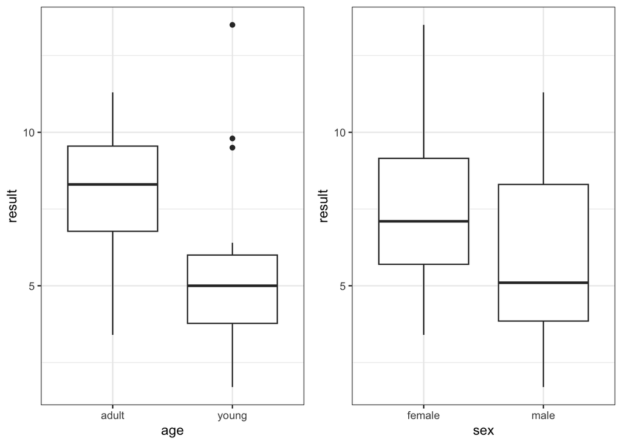

```r
p1 <- ggplot(data = datos, mapping = aes(x = age, y = result)) +
      geom_boxplot() +
      theme_bw()
p2 <- ggplot(data = datos, mapping = aes(x = sex, y = result)) +
      geom_boxplot() +
      theme_bw()
p3 <- ggplot(data = datos, mapping = aes(x = age, y = result, colour = sex)) +
      geom_boxplot() +
      theme_bw()

grid.arrange(p1, p2, ncol = 2)
```

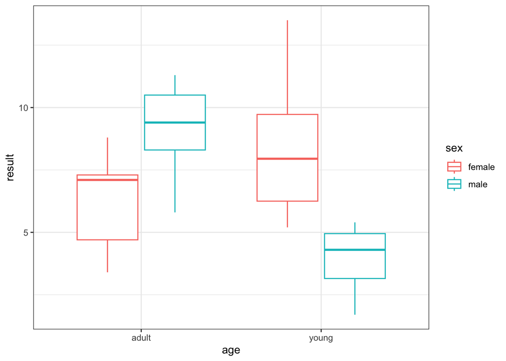

```r
p3
```

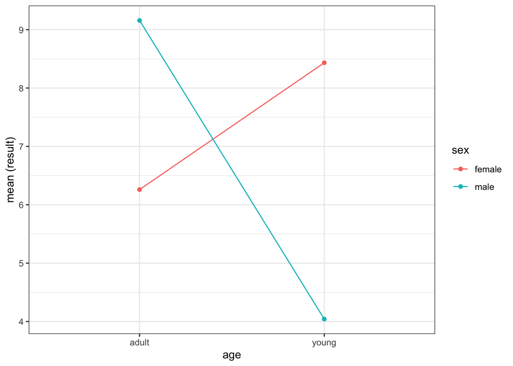

```r
ggplot(data = datos, aes(x = age, y = result, colour = sex, group = sex)) +
    stat_summary(fun = mean, geom = "point") +
    stat_summary(fun = mean, geom = "line") +
    labs(y  =  'mean (result)') +
    theme_bw()
```

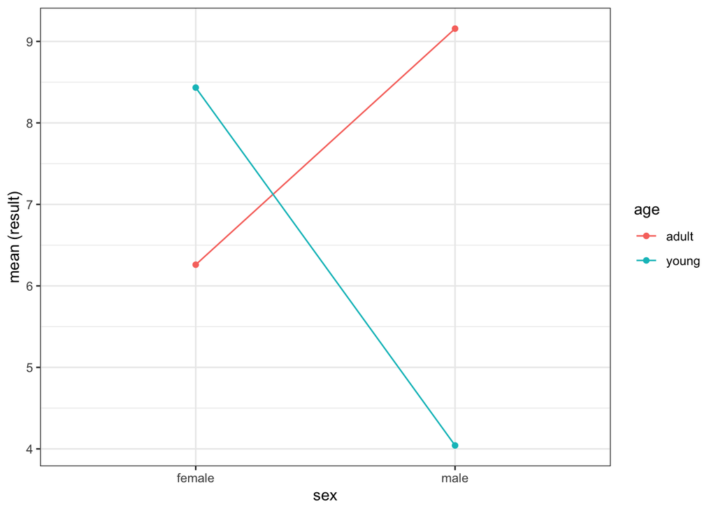

```r
ggplot(data = datos, aes(x = sex, y = result, colour = age, group = age)) +
    stat_summary(fun = mean, geom = "point") +
    stat_summary(fun = mean, geom = "line") +
    labs(y  =  'mean (result)') +
    theme_bw()
```

```r
anova_2vias <- aov(formula = result ~ sex*age, data = datos)
summary(anova_2vias)
```

```
##             Df Sum Sq Mean Sq F value  Pr(>F)
## sex          1  16.08   16.08   4.038  0.0550 .
## age          1  38.96   38.96   9.786  0.0043 **
## sex:age      1  89.61   89.61  22.509 6.6e-05 ***
## Residuals   26 103.51    3.98
## ---
## Signif. codes:  0 '***' 0.001 '**' 0.01 '*' 0.05 '.' 0.1 ' ' 1
```

```r
etaSquared(anova_2vias)
```

```
##             eta.sq eta.sq.part
## sex     0.04842176   0.1040130
## age     0.15699885   0.2734635
## sex:age 0.36110080   0.4640119
```

```r
#install.packages("emmeans")
library(emmeans)
aov2.emm = emmeans(anova_2vias, specs=~sex*age)
#Este modelo es correcto cuando NO hay interacción
emmeans(aov2.emm, pairwise~sex)
```

```
## NOTE: Results may be misleading due to involvement in interactions
```

```
## $emmeans
##  sex    emmean    SE df lower.CL upper.CL
##  female   7.35 0.604 26     6.10     8.59
##  male     6.60 0.474 26     5.62     7.57
##
## Results are averaged over the levels of: age
## Confidence level used: 0.95
##
## $contrasts
##  contrast      estimate    SE df t.ratio p.value
##  female - male    0.747 0.768 26   0.973  0.3396
##
## Results are averaged over the levels of: age
```

```r
emmeans(aov2.emm, pairwise~age)
```

```
## NOTE: Results may be misleading due to involvement in interactions
```

```
## $emmeans
##  age   emmean    SE df lower.CL upper.CL
##  adult   7.71 0.584 26     6.51     8.91
##  young   6.24 0.499 26     5.21     7.26
##
## Results are averaged over the levels of: sex
## Confidence level used: 0.95
##
## $contrasts
##  contrast      estimate    SE df t.ratio p.value
##  adult - young     1.47 0.768 26   1.915  0.0665
##
## Results are averaged over the levels of: sex
```

```r
emmeans(aov2.emm, pairwise~sex*age)
```

```
## $emmeans
##  sex    age   emmean    SE df lower.CL upper.CL
##  female adult   6.26 0.892 26     4.43     8.09
##  male   adult   9.16 0.754 26     7.61    10.71
##  female young   8.43 0.815 26     6.76    10.11
##  male   young   4.04 0.576 26     2.86     5.23
##
## Confidence level used: 0.95
##
## $contrasts
##  contrast                    estimate    SE df t.ratio p.value
##  female adult - male adult     -2.897 1.170 26  -2.480  0.0870
##  female adult - female young   -2.173 1.210 26  -1.799  0.2966
##  female adult - male young      2.218 1.060 26   2.089  0.1833
##  male adult - female young      0.724 1.110 26   0.652  0.9139
##  male adult - male young        5.115 0.949 26   5.391  0.0001
##  female young - male young      4.392 0.998 26   4.402  0.0009
##
## P value adjustment: tukey method for comparing a family of 4 estimates
```

## Ejemplo de Balluerka & Vergara, 2002

```r
id <- as.factor(c(1, 2, 3, 4, 5, 6, 7, 8, 9, 10, 11, 12, 13, 14, 15, 16, 17,
                       18, 19, 20, 21, 22, 23, 24))

resultado <- c(7,9,10,8,8,11,10,6,13,15,11,10, 6,5,4,7,4,6,8,5,10,9,6,8)
desarrollo <- as.factor(c("precoz", "precoz", "precoz", "precoz", "precoz", "precoz", "precoz", "precoz", "precoz", "precoz", "precoz", "precoz", "tardío", "tardío", "tardío", "tardío", "tardío", "tardío", "tardío", "tardío", "tardío", "tardío", "tardío", "tardío"))
comp_padres <- as.factor(c("a.mcomp", "a.mcomp", "a.mcomp", "a.mcomp", "b.pcomp", "b.pcomp", "b.pcomp", "b.pcomp","c.ambos", "c.ambos", "c.ambos", "c.ambos", "a.mcomp", "a.mcomp", "a.mcomp", "a.mcomp", "b.pcomp", "b.pcomp", "b.pcomp", "b.pcomp","c.ambos", "c.ambos", "c.ambos", "c.ambos"))

datos <- data.frame(id,desarrollo, comp_padres, resultado)
head(datos, 4)
```

```
##   id desarrollo comp_padres resultado
## 1  1     precoz     a.mcomp         7
## 2  2     precoz     a.mcomp         9
## 3  3     precoz     a.mcomp        10
## 4  4     precoz     a.mcomp         8
```

```r
datos %>%
  group_by(desarrollo, comp_padres)%>%
  skim(resultado)
```

Data summary

| Name | Piped data |
| --- | --- |
| Number of rows | 24 |
| Number of columns | 4 |
| _______________________ |  |
| Column type frequency: |  |
| numeric | 1 |
| ________________________ |  |
| Group variables | desarrollo, comp_padres |

**Variable type: numeric**

| skim_variable | desarrollo | comp_padres | n_missing | complete_rate | mean | sd | p0 | p25 | p50 | p75 | p100 | hist |
| --- | --- | --- | --- | --- | --- | --- | --- | --- | --- | --- | --- | --- |
| resultado | precoz | a.mcomp | 0 | 1 | 8.50 | 1.29 | 7 | 7.75 | 8.5 | 9.25 | 10 | ▇▇▁▇▇ |
| resultado | precoz | b.pcomp | 0 | 1 | 8.75 | 2.22 | 6 | 7.50 | 9.0 | 10.25 | 11 | ▇▇▁▇▇ |
| resultado | precoz | c.ambos | 0 | 1 | 12.25 | 2.22 | 10 | 10.75 | 12.0 | 13.50 | 15 | ▇▁▃▁▃ |
| resultado | tardío | a.mcomp | 0 | 1 | 5.50 | 1.29 | 4 | 4.75 | 5.5 | 6.25 | 7 | ▇▇▁▇▇ |
| resultado | tardío | b.pcomp | 0 | 1 | 5.75 | 1.71 | 4 | 4.75 | 5.5 | 6.50 | 8 | ▇▇▇▁▇ |
| resultado | tardío | c.ambos | 0 | 1 | 8.25 | 1.71 | 6 | 7.50 | 8.5 | 9.25 | 10 | ▇▁▇▇▇ |

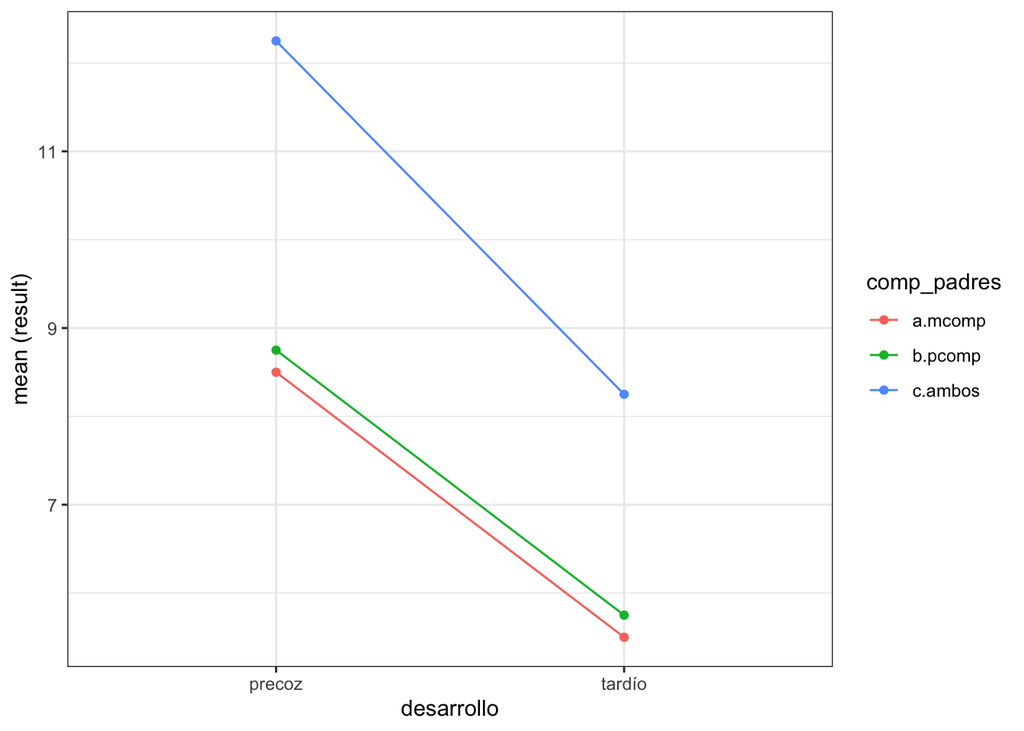

```r
ggplot(data = datos, aes(x = desarrollo, y = resultado, colour = comp_padres, group = comp_padres)) +
    stat_summary(fun = mean, geom = "point") +
    stat_summary(fun = mean, geom = "line") +
    labs(y  =  'mean (result)') +
    theme_bw()
```

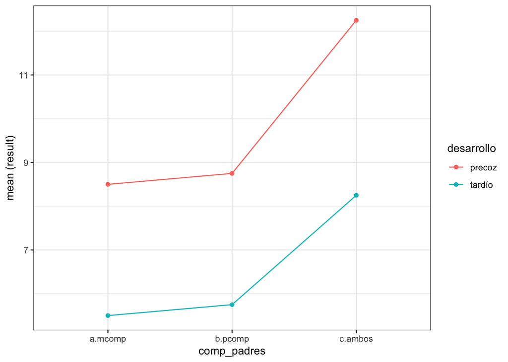

```r
ggplot(data = datos, aes(x = comp_padres, y = resultado, colour = desarrollo, group = desarrollo)) +
    stat_summary(fun = mean, geom = "point") +
    stat_summary(fun = mean, geom = "line") +
    labs(y  =  'mean (result)') +
    theme_bw()
```

```r
anova_simple1 <- aov(formula = resultado ~ comp_padres, data = datos)
summary(anova_simple1)
```

```
##             Df Sum Sq Mean Sq F value Pr(>F)
## comp_padres  2  52.33  26.167   4.396 0.0254 *
## Residuals   21 125.00   5.952
## ---
## Signif. codes:  0 '***' 0.001 '**' 0.01 '*' 0.05 '.' 0.1 ' ' 1
```

```r
anova_simple2 <- aov(formula = resultado ~ desarrollo, data = datos)
summary(anova_simple2)
```

```
##             Df Sum Sq Mean Sq F value  Pr(>F)
## desarrollo   1  66.67   66.67   13.25 0.00144 **
## Residuals   22 110.67    5.03
## ---
## Signif. codes:  0 '***' 0.001 '**' 0.01 '*' 0.05 '.' 0.1 ' ' 1
```

```r
anova_factorial1 <- aov(formula = resultado ~ comp_padres + desarrollo, data = datos)
summary(anova_factorial1)
```

```
##             Df Sum Sq Mean Sq F value   Pr(>F)
## comp_padres  2  52.33   26.17   8.971 0.001656 **
## desarrollo   1  66.67   66.67  22.857 0.000114 ***
## Residuals   20  58.33    2.92
## ---
## Signif. codes:  0 '***' 0.001 '**' 0.01 '*' 0.05 '.' 0.1 ' ' 1
```

```r
anova_factorial2 <- aov(formula = resultado ~ comp_padres * desarrollo, data = datos)
summary(anova_factorial2)
```

```
##                        Df Sum Sq Mean Sq F value   Pr(>F)
## comp_padres             2  52.33   26.17   8.263 0.002845 **
## desarrollo              1  66.67   66.67  21.053 0.000228 ***
## comp_padres:desarrollo  2   1.33    0.67   0.211 0.812124
## Residuals              18  57.00    3.17
## ---
## Signif. codes:  0 '***' 0.001 '**' 0.01 '*' 0.05 '.' 0.1 ' ' 1
```

```r
#install.packages("emmeans")
library(emmeans)
aov2.emm = emmeans(anova_factorial2, specs=~comp_padres * desarrollo)
#Este modelo es correcto cuando NO hay interacción
emmeans(aov2.emm, pairwise~comp_padres)
```

```
## NOTE: Results may be misleading due to involvement in interactions
```

```
## $emmeans
##  comp_padres emmean    SE df lower.CL upper.CL
##  a.mcomp       7.00 0.629 18     5.68     8.32
##  b.pcomp       7.25 0.629 18     5.93     8.57
##  c.ambos      10.25 0.629 18     8.93    11.57
##
## Results are averaged over the levels of: desarrollo
## Confidence level used: 0.95
##
## $contrasts
##  contrast          estimate   SE df t.ratio p.value
##  a.mcomp - b.pcomp    -0.25 0.89 18  -0.281  0.9575
##  a.mcomp - c.ambos    -3.25 0.89 18  -3.653  0.0049
##  b.pcomp - c.ambos    -3.00 0.89 18  -3.372  0.0091
##
## Results are averaged over the levels of: desarrollo
## P value adjustment: tukey method for comparing a family of 3 estimates
```

```r
emmeans(aov2.emm, pairwise~desarrollo)
```

```
## NOTE: Results may be misleading due to involvement in interactions
```

```
## $emmeans
##  desarrollo emmean    SE df lower.CL upper.CL
##  precoz       9.83 0.514 18     8.75    10.91
##  tardío       6.50 0.514 18     5.42     7.58
##
## Results are averaged over the levels of: comp_padres
## Confidence level used: 0.95
##
## $contrasts
##  contrast        estimate    SE df t.ratio p.value
##  precoz - tardío     3.33 0.726 18   4.588  0.0002
##
## Results are averaged over the levels of: comp_padres
```

```r
emmeans(aov2.emm, pairwise~desarrollo*comp_padres)
```

```
## $emmeans
##  desarrollo comp_padres emmean   SE df lower.CL upper.CL
##  precoz     a.mcomp       8.50 0.89 18     6.63    10.37
##  tardío     a.mcomp       5.50 0.89 18     3.63     7.37
##  precoz     b.pcomp       8.75 0.89 18     6.88    10.62
##  tardío     b.pcomp       5.75 0.89 18     3.88     7.62
##  precoz     c.ambos      12.25 0.89 18    10.38    14.12
##  tardío     c.ambos       8.25 0.89 18     6.38    10.12
##
## Confidence level used: 0.95
##
## $contrasts
##  contrast                        estimate   SE df t.ratio p.value
##  precoz a.mcomp - tardío a.mcomp     3.00 1.26 18   2.384  0.2133
##  precoz a.mcomp - precoz b.pcomp    -0.25 1.26 18  -0.199  0.9999
##  precoz a.mcomp - tardío b.pcomp     2.75 1.26 18   2.185  0.2913
##  precoz a.mcomp - precoz c.ambos    -3.75 1.26 18  -2.980  0.0735
##  precoz a.mcomp - tardío c.ambos     0.25 1.26 18   0.199  0.9999
##  tardío a.mcomp - precoz b.pcomp    -3.25 1.26 18  -2.583  0.1524
##  tardío a.mcomp - tardío b.pcomp    -0.25 1.26 18  -0.199  0.9999
##  tardío a.mcomp - precoz c.ambos    -6.75 1.26 18  -5.364  0.0005
##  tardío a.mcomp - tardío c.ambos    -2.75 1.26 18  -2.185  0.2913
##  precoz b.pcomp - tardío b.pcomp     3.00 1.26 18   2.384  0.2133
##  precoz b.pcomp - precoz c.ambos    -3.50 1.26 18  -2.782  0.1067
##  precoz b.pcomp - tardío c.ambos     0.50 1.26 18   0.397  0.9985
##  tardío b.pcomp - precoz c.ambos    -6.50 1.26 18  -5.166  0.0008
##  tardío b.pcomp - tardío c.ambos    -2.50 1.26 18  -1.987  0.3866
##  precoz c.ambos - tardío c.ambos     4.00 1.26 18   3.179  0.0499
##
## P value adjustment: tukey method for comparing a family of 6 estimates
```

## Anova Factorial (otro ejemplo)

Queremos estudiar la influencia que tienen el el sexo del profesor y el tipo de colegio sobre los sintomas el clima escolar. Para ello se mide con una escala de clima escolar (variable cuantitativa dependiente) tres tipos de colegios (municipal, PS y PP) y estudiantes (H y M).

```r
clima <- c(15.29, 15.89, 16.02, 16.56, 15.46, 16.91, 16.99, 17.27, 16.85,
                 16.35, 17.23, 17.81, 17.74, 18.02, 18.37, 12.07, 12.42, 12.73,
                 13.02, 12.05, 12.92, 13.01, 12.21, 13.49, 14.01, 13.30, 12.82,
                 12.49, 13.55, 14.53)
sexo <- c(rep(c("Masculino", "Femenino"), c(15,15)))
colegio <- rep(c("a.M","b.PS", "c.PP"), each = 5, times = 2)
datos <- data.frame(sexo = sexo, colegio = as.factor(colegio),
                    clima = clima)
head(datos)
```

```
##        sexo colegio clima
## 1 Masculino     a.M 15.29
## 2 Masculino     a.M 15.89
## 3 Masculino     a.M 16.02
## 4 Masculino     a.M 16.56
## 5 Masculino     a.M 15.46
## 6 Masculino    b.PS 16.91
```

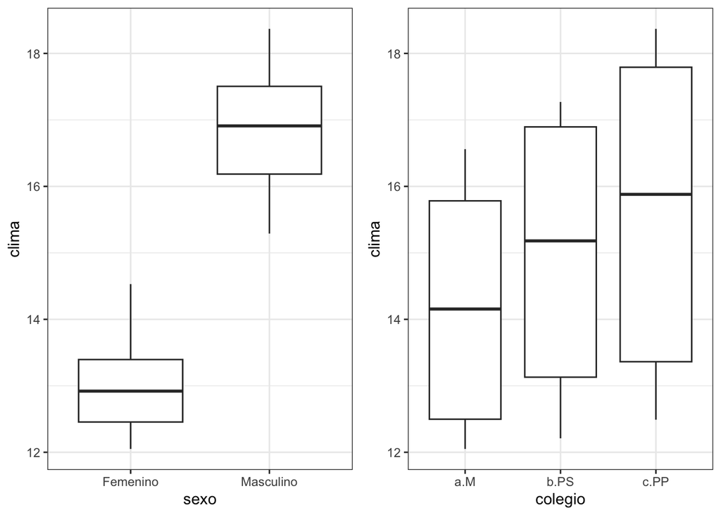

```r
library(ggplot2)
library(gridExtra)

p1 <- ggplot(data = datos, aes(x = sexo, y = clima)) +
      geom_boxplot() + theme_bw()
p2 <- ggplot(data = datos, aes(x = colegio, y = clima)) +
      geom_boxplot() + theme_bw()
p3 <- ggplot(data = datos, aes(x = sexo, y = clima, colour = colegio)) +
      geom_boxplot() + theme_bw()

grid.arrange(p1, p2, ncol = 2)
```

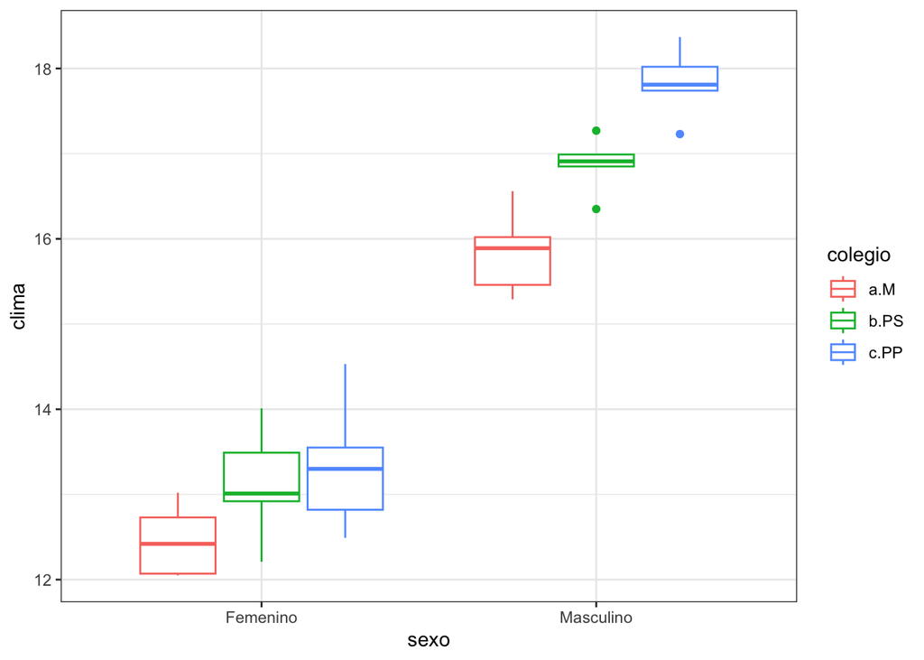

```r
p3
```

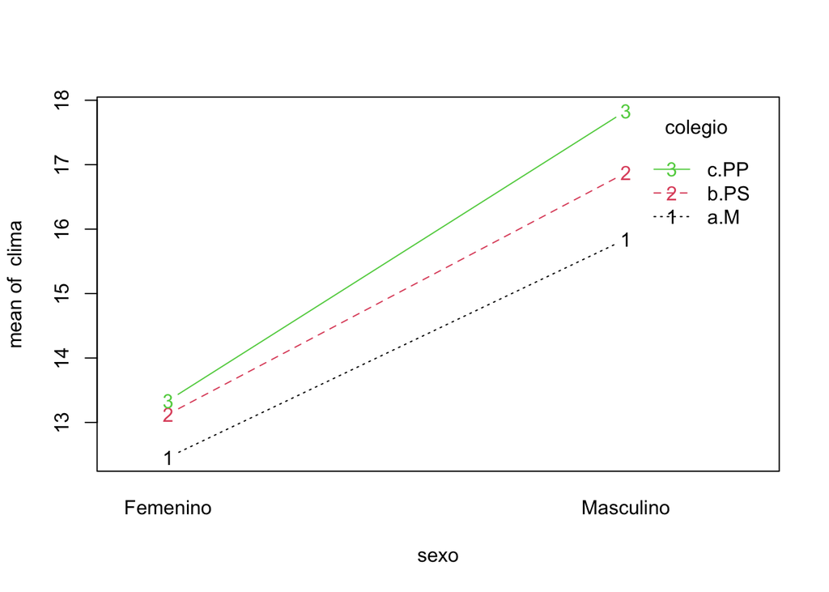

```r
interaction.plot(sexo, colegio, clima, data = datos, col = 1:3, type = "b")
```

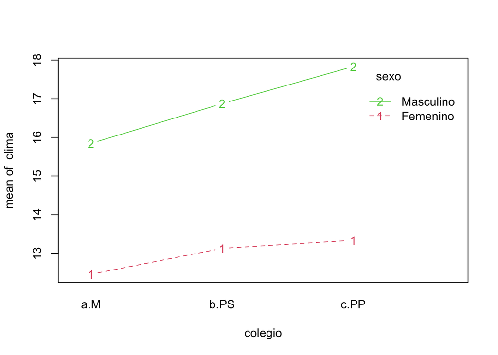

```r
interaction.plot(colegio, sexo, clima, data = datos,col = 2:3, type = "b")
```

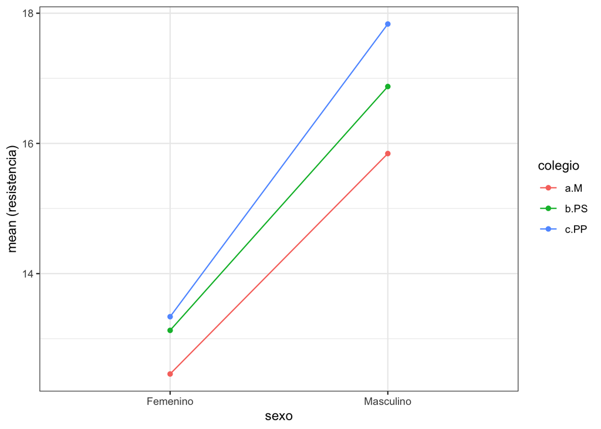

```r
ggplot(data = datos, aes(x = sexo, y = clima, colour = colegio,
                         group = colegio)) +
    stat_summary(fun = mean, geom = "point") +
    stat_summary(fun = mean, geom = "line") +
    labs(y  =  'mean (resistencia)') +
    theme_bw()
```

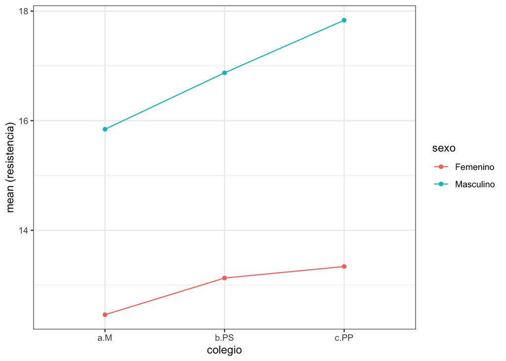

```r
ggplot(data = datos, aes(x = colegio, y = clima, colour = sexo,
                         group = sexo)) +
    stat_summary(fun = mean, geom = "point") +
    stat_summary(fun = mean, geom = "line") +
    labs(y  =  'mean (resistencia)') +
    theme_bw()
```

```r
anova <- aov(clima ~ colegio + sexo, data = datos)
summary(anova)
```

```
##             Df Sum Sq Mean Sq F value   Pr(>F)
## colegio      2  10.41    5.21   15.53 3.65e-05 ***
## sexo         1 112.68  112.68  336.02  < 2e-16 ***
## Residuals   26   8.72    0.34
## ---
## Signif. codes:  0 '***' 0.001 '**' 0.01 '*' 0.05 '.' 0.1 ' ' 1
```

```r
anova <- aov(clima ~ colegio * sexo, data = datos)
summary(anova)
```

```
##              Df Sum Sq Mean Sq F value   Pr(>F)
## colegio       2  10.41    5.21  17.563 2.00e-05 ***
## sexo          1 112.68  112.68 380.082 3.19e-16 ***
## colegio:sexo  2   1.60    0.80   2.705   0.0873 .
## Residuals    24   7.11    0.30
## ---
## Signif. codes:  0 '***' 0.001 '**' 0.01 '*' 0.05 '.' 0.1 ' ' 1
```

```r
#install.packages("lsr")

etaSquared(anova)
```

```
##                  eta.sq eta.sq.part
## colegio      0.07900327   0.5940887
## sexo         0.85485219   0.9406061
## colegio:sexo 0.01216553   0.1839235
```